# Power simulation for waterlogging experiment

Hamish McLean

2022-02-03

# Power simulation for waterlogging experiment

The purpose of this notebook is to simulate the waterlogging experiment and calculate power for different experimental designs.

## Parameters

```r
trees <- 300
treesPerPot <- 3

potsPerPlot <- 5
treesPerPlot <- treesPerPot * potsPerPlot
plots <- trees %/% treesPerPlot

treatments <- 5
blocks <- plots %/% treatments
remainder <- trees - blocks * treatments * treesPerPlot

pointsPerTree <- 3
pointsPerPlot <- pointsPerTree * treesPerPlot

infectionRate <- 0.15
effect <- 1.5


data.table(
    factor = c("treesPerPlot", "plots", "treatments", "blocks", "remainder",
               "infectionRate", "effect"),
    value = c(treesPerPlot, plots, treatments, blocks, remainder,
              infectionRate, effect)
)
```

```
##           factor value
## 1:  treesPerPlot 15.00
## 2:         plots 20.00
## 3:    treatments  5.00
## 4:        blocks  4.00
## 5:     remainder  0.00
## 6: infectionRate  0.15
## 7:        effect  1.50
```

## Single experiment

For a single iteration of the experiment, canker infections are randomly sampled from a binomial distribution, $y\sim{}Bin(p, n)$, with probability estimated as `infectionRate` and n as the number of inoculation points per plot as `pointsPerPlot`.

```r
singleExperiment <- function(treatment, blocks, pointsPerPlot, infectionRate){
    treatment <- rep(treatment, blocks)
    incidence <- rbinom(blocks, pointsPerPlot, infectionRate)/pointsPerPlot
    n <- rep(pointsPerPlot, blocks)
    data.table(treatment, incidence, n)
}

singleData <- rbind(
  singleExperiment("control", blocks, pointsPerPlot, infectionRate),
  singleExperiment("waterlogged", blocks, pointsPerPlot, infectionRate * effect)
)

singleModel <- glm(incidence ~ treatment, family = binomial(link = 'logit'),
    data = singleData, weights = n)

summary(singleModel)
```

```
##
## Call:
## glm(formula = incidence ~ treatment, family = binomial(link = "logit"),
##     data = singleData, weights = n)
##
## Deviance Residuals:
##      Min        1Q    Median        3Q       Max
## -1.34903  -0.32548  -0.00117   0.31178   1.22968
##
## Coefficients:
##                      Estimate Std. Error z value Pr(>|z|)
## (Intercept)           -1.7789     0.2120  -8.390   <2e-16 ***
## treatmentwaterlogged   0.4606     0.2798   1.646   0.0998 .
## ---
## Signif. codes:  0 '***' 0.001 '**' 0.01 '*' 0.05 '.' 0.1 ' ' 1
##
## (Dispersion parameter for binomial family taken to be 1)
##
##     Null deviance: 7.0542  on 7  degrees of freedom
## Residual deviance: 4.3042  on 6  degrees of freedom
## AIC: 37.894
##
## Number of Fisher Scoring iterations: 4
```

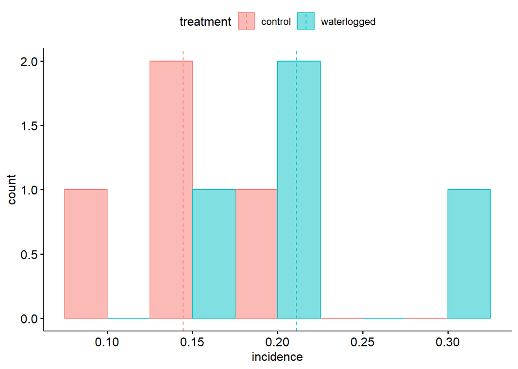

```r
gghistogram(data = singleData,
          x = "incidence",
          add = "mean",
          binwidth = 0.05,
          color = "treatment", fill = "treatment",
          position = "dodge")
```

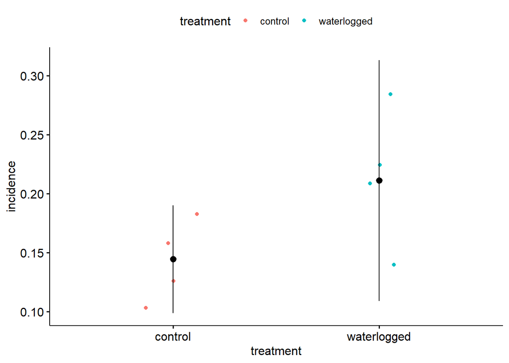

```r
          #palette = c("#00AFBB", "#E7B800"))

ggstripchart(data = singleData,
             x = "treatment",
             y = "incidence",
             add = "mean_ci",
             color = "treatment",
             add.params = list(color = "black")) #+
```

```r
  #stat_compare_means(method = 'kruskal.test')#comparison = list(c("control", "waterlogged")))
```

## Power calculation

To calculate power, the simulation must be repeated many times. Power is calculated as the proportion of p values less than alpha (0.05 by default) after fitting each repeat to a glm. For this implementation, a matrix (with `blocks` rows and `iterations` columns) of random values sampled from a binomial distribution with each column as a single iteration of the experiment. A glm is fit to each column and the p values recorded.

```r
#' Simulate power by generating data from a binomial distribution,
#' fitting to a binomial glm and calculating power.
simulatePower <- function(iterations, blocks, points, rate, effect, alpha=0.05){

    # Generate data
    control <- replicate(iterations, rbinom(blocks, points, rate)/points)
    waterlogged <- replicate(iterations,
                             rbinom(blocks, points, rate * effect)/points)
    data <- abind(control, waterlogged, along = 1)

    # Fit model and calculate p values
    treatment <- c(rep("control", blocks), rep("waterlogged", blocks))
    n <- rep(points, 2 * blocks)
    pValues <- apply(data, 2, function(y) calculateP(y, treatment, n))

    # Calculate power
    sum(pValues <= alpha) / length(pValues)
}

#' Fit a binomial glm and return the p value.
calculateP <- function(y, x, weights){
    model <- glm(y ~ x, family = binomial(link = 'logit'), weights = weights)
    coef(summary(model))[2,4]  # return p value from model
}

#simulatePower(iterations = 1000, blocks, pointsPerPlot, infectionRate, effect)
```

## Varying parameters

To compare power for different experimental designs, the experimental parameters are varied according to different designs. For this, a table is generated from every combination of the variable parameters. The power simulation is then run for each combination of parameters.

```r
trees <- 300
treesPerPot <- 3
pointsPerTree <- 3

potsPerPlot <- 4
treatments <- c(3, 5, 7)
infectionRate <- c(0.1, 0.15, 0.2)
effect <- c(1.4, 1.7, 2)

experiments <- expand.grid(
    potsPerPlot = potsPerPlot,
    treatments = treatments,
    rate = infectionRate,
    effect = effect
) %>%
    as.data.table() %>%
    .[, treesPerPlot := treesPerPot * potsPerPlot] %>%
    .[, plots := trees %/% treesPerPlot] %>%
    .[, blocks := plots %/% treatments] %>%
    .[, points := pointsPerTree * treesPerPlot] %>%
    .[, remainder := trees - blocks * treatments * treesPerPlot]
```

```r
iterations <- 1000

#' Simulate power for each combination of parameters in `experiments`.
#' This function takes a long time to run!
powerComparison <- function(iterations, experiments){
    experiments[, power := mapply(simulatePower, iterations,
                                  blocks, points, rate, effect)]
}

# This takes a long time to run!
tic(paste(nrow(data), "simulations of", iterations, "iterations"))
powers <- powerComparison(iterations, experiments)
toc()
```

```
##  simulations of 1000 iterations: 96.55 sec elapsed
```

```r
#View(powers)
```

## Results

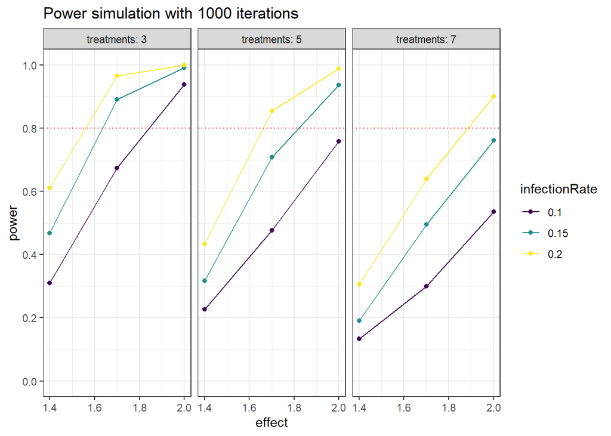

```r
ggplot(powers, aes(effect, power, group = rate,
                 color = cut(rate, breaks = 3, labels = infectionRate))) +
    geom_point() +
    geom_line() +
    geom_hline(yintercept = 0.8, linetype = "dotted", col = "red") +
    scale_y_continuous(breaks = c(0, 0.2, 0.4, 0.6, 0.8, 1), limits = c(0, 1)) +
    #facet_grid(potsPerPlot ~ treatments, labeller = label_both) +
    facet_wrap(~treatments, labeller = label_both) +
    scale_color_viridis_d(name = "infectionRate") +
    theme_bw() +
    ggtitle(paste("Power simulation with", iterations, "iterations"))
```

`infectionRate` and `effect` size has a large effect on power. This makes it difficult to reliably predict power as the values of these variables must be estimated.